# A Multiple Linear Model for Toronto and Mississauga House Prices

Tanyilan, Id 1004701548

December 5, 2020

## I. Data Wrangling

**1.1 Sampling Data**

We randomly selected 150 cases from the raw data. The id of the cases are

```
##   [1]  51  99 114 131  60 158  17 133  30  92 145 142 150 148 118 117   4 115
##  [19]  64  70  93  15  53  22  83 140 151 119 144 107  39 149 143 146 103  82
##  [37] 106  76   6  55   7 105  85  33  84  80 153 101  87  54  36  10 111  91
##  [55]  68 108  58  61  98 122  79  74  97   1 147 116  77 152 113  37 159  24
##  [73]  63  96   9  88  40  14  62 154 100  71  49   3 136  27  47  56  50  73
##  [91]  72  19  31  81  67 137  35  21  69  13  16  95 160 135 156  32 112  28
## [109]   8  89  90  86 110 157  75  57 102 126 134 138  65  48  66 141  45  11
## [127] 125  78   5   2 155  52 104 132 139  25 109  43  38  44  42  29  46  20
## [145]  94  23  34  41  12  26
```

**1.2 Data Cleaning**

Independent variable ‘maxsqfoot’ is removed because

- We don’t need two variables representing the size of the property. ’lotsize’is another area variable.
- We choose ‘lotsize’ instead of ‘maxsqfoot’ because there are 98 missing values for ‘maxsqfoot’.

Also, we remove 11 data sets containing ‘na’ (missing values).

## II. Exploratory Data Analysis

**2.1 Classify Variables**

- Categorical Variable(s): location
- Discrete Variable(s): Number of bedrooms(bedroom), Number of bathrooms(bathroom), Number of parking spots(parking), Maximum square footage(maxsqfoot, removed)
- Continuous Variables: Sale price(sale), List price(list), Property tax(taxes), Lot size(lotsize), Frontage(lotwidth, removed), Length(lotlength, removed)

**2.2 Correlation Matrix**

TABLE 2.1: Correlation Coefficient Matrix

|  | sale | list | bedroom | bathroom | taxes | parking | lotsize | location |
| --- | --- | --- | --- | --- | --- | --- | --- | --- |
| sale | 1 |  |  |  |  |  |  |  |
| list | 0.9874 | 1 |  |  |  |  |  |  |
| bedroom | 0.4395 | 0.4436 | 1 |  |  |  |  |  |
| bathroom | 0.6788 | 0.6955 | 0.539 | 1 |  |  |  |  |
| taxes | 0.8087 | 0.7926 | 0.3931 | 0.5251 | 1 |  |  |  |
| parking | 0.2486 | 0.2874 | 0.3543 | 0.3654 | 0.4287 | 1 |  |  |
| lotsize | 0.3714 | 0.3873 | 0.2726 | 0.3175 | 0.5463 | 0.741 | 1 |  |
| location | 0.0948 | 0.0585 | -0.1491 | -0.163 | -0.1291 | -0.771 | -0.5589 | 1 |

Highest to Lowest correlation coefficient with ‘sale price’:

1. Last list price (list): 0.9874,
2. Property tax (taxes): 0.8087,
3. Number of bathrooms (bathroom): 0.6788,
4. Number of bedrooms (bedroom): 0.4395,
5. Lotsize (lotsize): 0.3714,
6. Number of parking spots (parking): 0.2486
7. Location of the property (location): 0.0948

**2.2 Scatterplot Matrix**

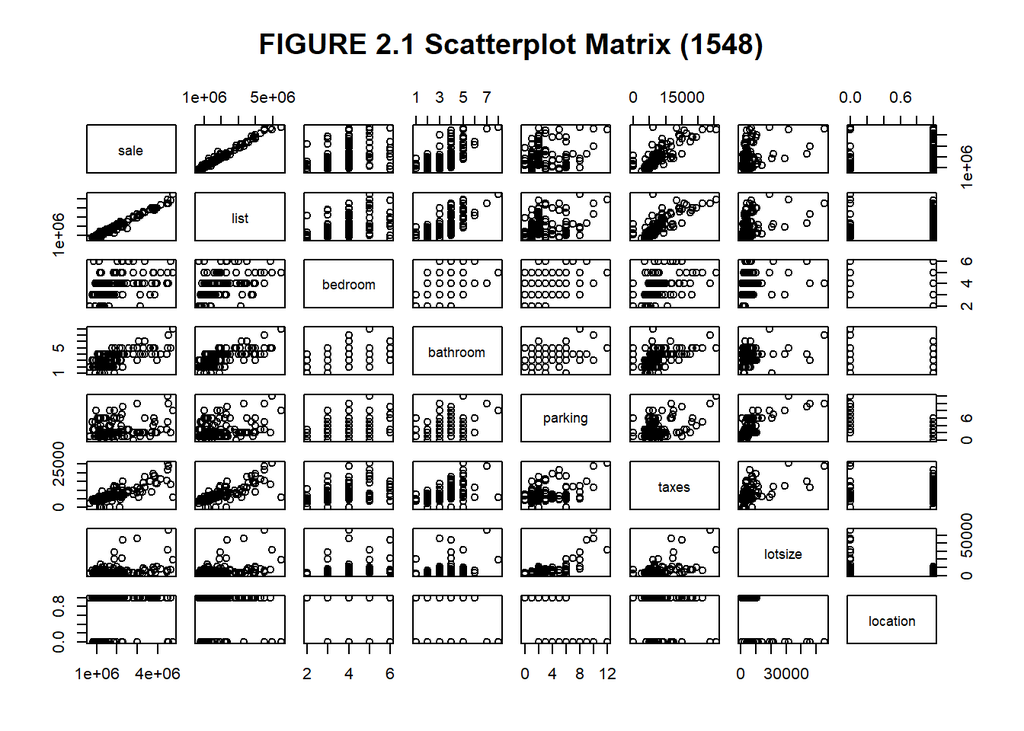

2.2.1 Violate The Constant Variance Assumption

Take a look at the first row except the dummy variable “location”; the scatter plots are approximately positively related except for the “lotsize”. Points on the last graph are centered at the left-bottom corner.

Thus, we guess that the data of ‘lotsize’ violate the constant variance assumption.

2.2.2 The Standardized Residuals Plot of ‘lotsize’

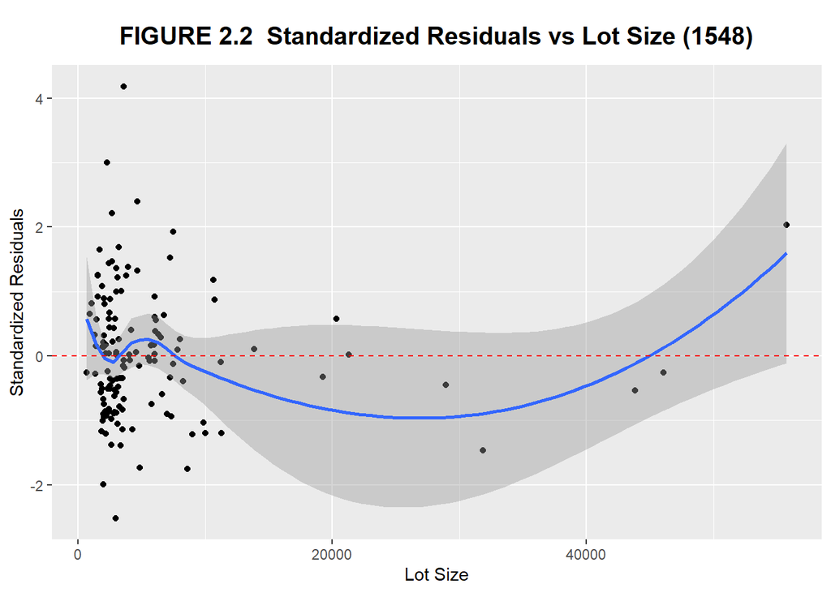

The residuals do not roughly form a horizontal band around the zero line (red), suggesting that the error terms’ variance are not constant. The conclusion proves that the constant variance assumption is not satisfied.

## III. Methods and Model

**3.1 Fitted Linear Regression Model**

3.1.1 Summary Table

TABLE 2.2: Summary of the Linear Regression Model Coefficient

|  | Estimate | Std. Error | t value | Pr(>\|t\|) |
| --- | --- | --- | --- | --- |
| (Intercept) | 100436.1181 | 68988.8890 | 1.4558 | 0.1478 |
| list | 0.8325 | 0.0242 | 34.3528 | 0.0000 |
| bedroom | 11935.7999 | 14318.8585 | 0.8336 | 0.4060 |
| bathroom | 7379.2088 | 14702.6122 | 0.5019 | 0.6166 |
| parking | -21769.6909 | 10664.8601 | -2.0413 | 0.0432 |
| taxes | 22.2828 | 4.9416 | 4.5093 | 0.0000 |
| lotsize | 1.5093 | 2.4429 | 0.6179 | 0.5377 |
| location | 58072.3904 | 52089.9799 | 1.1148 | 0.2670 |

3.1.2 Fitted Multiple Linear Regression Model (Full)

We get the full model given by:

$sale = 100436.12 + 0.83 \times list + 11935.80 \times bedroom + 7379.21 \times bathroom - 21769.70 \times parking + 22.28 \times taxes + 1.51 \times lotsize + 58072.40 \times location$

Note: location = 1 if the property is in Toronto, otherwise 0.

3.1.3 Significance of Variables

List price, parking spots, and property taxes are significant because the p-values of the three variables are smaller than the significance level 0.05. We are able to reject the null hypothesis that the coefficients of these variables are zero.

Keep all other variables constant, as the list price increased by 1, the property’s average sale price will increase by 0.83. Keep all other variables constant, as the parking spots increased by 1, the property’s average sale price will decrease by 21769.7. Keep all other variables constant, as the property tax increased by 1, the property’s average sale price will increase by 22.28.

**3.2 Find A Parsimonious Model (Backward, AIC)**

We get the final model according to the AIC values using backward regression is given by

$sale = 195400 + 0.85 \times list - 25200.70 \times parking + 22.6 \times taxes$

**3.3 Find A Parsimonious Model (Backward, BIC)**

We get the final model according to the BIC values using backward regression is given by

$sale = 195400 + 0.85 \times list - 25200.70 \times parking + 22.6 \times taxes$

**3.4 Check Multicollinearity**

Global F-test for the final model is significant, equals to 2187. One of the partial F-test of three variable, list price, is much more significant than others. This indicates there does not exist multicollinearity, but one variable is more significant than other two.

**3.5 Summary**

The final model is given by:

$sale = 195400 + 0.85 \times list - 25200.70 \times parking + 22.60 \times taxes$

Keep all other variables constant, as the list price increased by 1, the property’s average sale price will increase by 0.85. Keep all other variables constant, as the parking spots increased by 1, the property’s average sale price will decrease by 25200.7. Keep all other variables constant, as the property tax increased by 1, the property’s average sale price will increase by 22.6.

## IV. Discussions and Limitations

**4.1 Diagnostic Plots**

### FIGURE 4.1 Diagnostic Plots (1548)

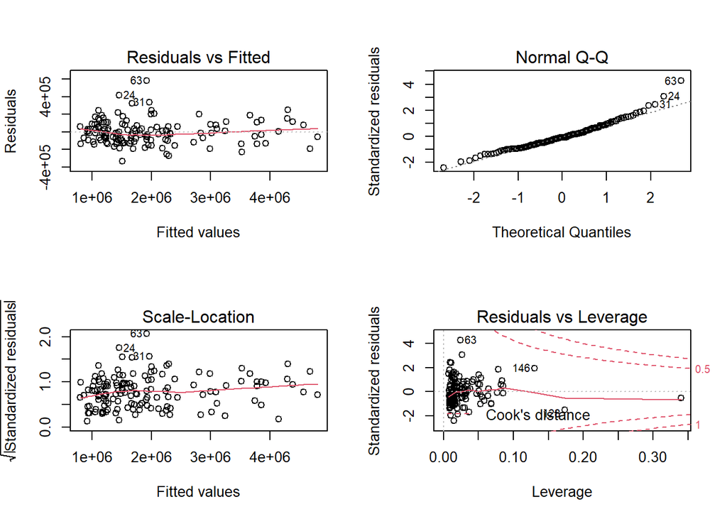

**4.2 Interpretation Diagnostic Plots**

4.2.1 Residual vs Fitted

In this case, the residuals are approximately randomly distributed around the horizontal zero line. This indicates that the residuals and the fitted values are uncorrelated. The assumption of equal variance (homoscedasticity) is satisfied.

4.2.2 Normal Q-Q

Most of the points follow the theoretical normal line. This indicates that the residuals are normally distributed. The assumption of the normal error MLR is satisfied.

4.2.3 Scale-Location

There is no obvious pattern shown in the graph. This indicates that the residuals are spread equally along with the ranges of predictors. The assumption of equal variance (homoscedasticity) is satisfied.

**4.3 Future Work**

- We could use box cox transformation to improve our model by making some of the variables more normally distributed.
- We could add more independent variables that may affect the sale price of properties.